# R Notebook

```r
library(tokenizers)
library(text2vec)
library(readr)
library(dplyr)
library(stringr)
library(purrr)
```

```r
library(forcats)
library(ggplot2)
library(glmnet)
library(doParallel)
library(Matrix)
library(broom)
library(tidyr)
library(tibble)
library(devtools)
library(wordVectors)
library(ggrepel)
library(apcluster)
library(caret)
library(tidyverse)
library(textreuse)
# Code to clean meta data

us_items <- read_csv("C:/Users/Joshua/Documents/rdata/data/us-items.csv",
                     col_types = cols(
  .default = col_character(),
  document_id = col_character(),
  publication_date = col_date(format = ""),
  release_date = col_date(format = ""),
  volume_current = col_integer(),
  volume_total = col_integer(),
  page_count = col_integer()
))

us_authors <- read_csv("C:/Users/Joshua/Documents/rdata/data/us-authors.csv",
                       col_types = cols(
  document_id = col_character(),
  author = col_character(),
  birth_year = col_character(),
  death_year = col_integer(),
  marc_dates = col_character(),
  byline = col_character()
))
us_subjects <- read_csv("C:/Users/Joshua/Documents/rdata/data/us-subjects.csv", col_types = cols(
  document_id = col_character(),
  subject_source = col_character(),
  subject_type = col_character(),
  subject = col_character()
))

us_authors <- read_csv("C:/Users/Joshua/Documents/rdata/data/us-authors.csv",
                       col_types = cols(.default = col_character()))

get_year <- function(x) { as.integer(str_extract(x, "\\d{4}")) }


pick <- function(x, y) { ifelse(!is.na(x), x, y) }

us_authors <- us_authors %>%
  mutate(birth_year = get_year(birth_year),
         death_year = get_year(death_year),
         creator = pick(author, byline))

us_subjects_moml <- us_subjects %>%
  filter(subject_source == "MOML",
         subject != "US") %>%
  distinct(document_id, subject)

us_subjects_loc <- us_subjects %>%
  filter(subject_source == "LOC")

rm(us_subjects)

us_items <- read_csv("C:/Users/Joshua/Documents/rdata/data/us-items.csv",
                     col_types = cols(
                         .default = col_character(),
                         publication_date = col_date(format = ""),
                         release_date = col_date(format = ""),
                         volume_current = col_integer(),
                         volume_total = col_integer(),
                         page_count = col_integer()
                       ))

clean_place <- function(x) {
  str_split(x, ",", n = 2) %>%
    map_chr(1) %>%
    str_replace_all("[[:punct:]]", "")
}

us_items <- us_items %>%
  mutate(city = clean_place(imprint_city),
         city = fct_recode(city,
                           "Unknown" = "Sl",
                           "Unknown" = "US",
                           "New York" = "NewYork",
                           "Boston" = "Boston New York",
                           "Cambridge" = "Cambridge Mass",
                           "New York" = "New York City",
                           "Washington" = "Washington DC"),
         publication_year = lubridate::year(publication_date)) %>%
  filter(publication_year > 1795,
         publication_year < 1925)
```

This text reuse notebook is using document level data not pages or paragraphs.

```r
files <- list.files("C:/Users/Joshua/Documents/rdata/railroaddata/railroads_documents",
                   pattern = "*.txt",
                   full.names = TRUE)
```

I was unable to create my corpus using the `dir` function as it returned an error message about character strings.

`dir <- list.files("list.files("C:/Users/Joshua/Documents/rdata/railroaddata/railroads_documents", pattern = "*.txt", full.names = TRUE) corpus <- TextReuseCorpus(dir = dir, tokenizer = tokenize_ngrams, n = 5, progress = FALSE)`

The textreuse vignette https://github.com/ropensci/textreuse/blob/master/vignettes/textreuse-introduction.Rmd stated that the corpus could be created using a directory of files, so I chose this method.

```r
corpus <- TextReuseCorpus(list.files("C:/Users/Joshua/Documents/rdata/railroaddata/railroads_documents",
                   pattern = "*.txt",
                   full.names = TRUE), tokenizer = tokenize_ngrams, n = 5,
                          progress = FALSE)
#This resulted in the following documents being skipped because they had too few words to create at least two n-grams with n=5: '19002548900', '20001390400', '20002772300'.
```

Next, I created a Pairwise comparison.

```r
comparisons <- pairwise_compare(corpus, jaccard_similarity, progress = FALSE)
comparisons[1:4, 1:4]
```

```
##             19000078700  19000156500  19000630400  19001178400
## 19000078700          NA 0.0002088955 0.0002062387 0.0003235348
## 19000156500          NA           NA 0.0001860530 0.0001721763
## 19000630400          NA           NA           NA 0.0001878463
## 19001178400          NA           NA           NA           NA
```

```r
#Rounding did not work
#comparisons <- pairwise_compare(corpus, jaccard_similarity, progress = FALSE)
#round(comparisons[1:3, 1:3], digits = 3)
```

Here the matrix is converted to a data frame and only the results with a score greater than 0.1 are kept.

```r
candidates <- pairwise_candidates(comparisons)
candidates[candidates$score > 0.1, ]
```

```
## # A tibble: 47 × 3
##              a           b     score
##          <chr>       <chr>     <dbl>
## 1  19002066300 20000992500 0.2198121
## 2  19002536200 19003002301 0.2324439
## 3  19002536200 19003002302 0.2448200
## 4  19002540100 20001386400 0.3002330
## 5  19002541000 19003005000 0.6124408
## 6  19002550100 19002551101 0.2496993
## 7  19002550100 19002551102 0.2531151
## 8  19002550100 19002552901 0.2220437
## 9  19002550100 19002552902 0.1668593
## 10 19002550100 19002554701 0.2507572
## # ... with 37 more rows
```

Minhash & Locality-sensitive hashing

The `pairwise` approach can be time consuming due to the number of comparisons. However, not all of the comparisons are useful and therefore need not be generated (this includes texts matched against themselves). Therefore, using a combination of Minhash & Locality-sensitive hashing can be more effective.

```r
minhash <- minhash_generator(n = 240, seed = 3552)
head(minhash(c("turn tokens into", "tokens into hashes", "into hashes fast")))
```

```
## [1] -1067902788  -349477925 -1306490031  -926753052 -1222296305 -1443723653
```

Now the corpus needs to be loaded using the `minhash` function. This creates a corpus with minhashes. It is also necessary to create a minhash signature by passing our minhash function to the minhash_func = parameter.

```r
corpus2 <- TextReuseCorpus(list.files("C:/Users/Joshua/Documents/rdata/railroaddata/railroads_documents",
                   pattern = "*.txt",
                   full.names = TRUE), tokenizer = tokenize_ngrams, n = 5,
                          minhash_func = minhash, keep_tokens = TRUE,
                          progress = FALSE)
#The following documents were skipped because they has too few words to create at least two n-grams with n = 5: '19002548900', '20001390400', '20002772300'
```

```r
head(minhashes(corpus2[[1]]))
```

```
## [1] -2147202554 -2147257050 -2147263129 -2147261142 -2145813290 -2146290874
```

```r
length(minhashes(corpus2[[1]]))
```

```
## [1] 240
```

```r
lsh_threshold(h = 100, b = 50)
```

```
## [1] 0.1414214
```

```r
buckets <- lsh(corpus2, bands = 80, progress = FALSE)
buckets
```

```
## # A tibble: 23,520 × 2
##            doc                          buckets
##          <chr>                            <chr>
## 1  19000078700 40e53e738a1a019e452f25d3f5cabad4
## 2  19000078700 ed5a425df5fecd483598ec2487799ff3
## 3  19000078700 2c6c59307be3c48d84f3699d3c5e9cc6
## 4  19000078700 b835dbdb2e3abed29a6e3e26caf3d87b
## 5  19000078700 bc24c649a0b1830b4b6347a5f57e6ca9
## 6  19000078700 776f3e177dfa23e3c3d99303860cef58
## 7  19000078700 25f3a19b4d7c096e2e1129b29fbdb0f2
## 8  19000078700 d468acf23847bef8d6bf8822cc94973f
## 9  19000078700 a126a7c54e8c5be3d00283d5f60163f2
## 10 19000078700 4c4a7c2f1e7abf0b9f971f34155e65d7
## # ... with 23,510 more rows
```

```r
baxter_matches <- lsh_query(buckets, "19000630400")
baxter_matches
```

```
## # A tibble: 0 × 2
## # ... with 2 variables: a <chr>, b <chr>
```

```r
candidates <- lsh_candidates(buckets)
candidates
```

```
## # A tibble: 27 × 3
##              a           b score
##          <chr>       <chr> <dbl>
## 1  19002066300 20000992500    NA
## 2  19002536200 19003002302    NA
## 3  19002540100 20001386400    NA
## 4  19002541000 19003005000    NA
## 5  19002550100 19002551101    NA
## 6  19002550100 19002551102    NA
## 7  19002550100 19002554701    NA
## 8  19002551101 19002552901    NA
## 9  19002551101 19002554701    NA
## 10 19002551101 19007710400    NA
## # ... with 17 more rows
```

```r
lsh_compare(candidates, corpus, jaccard_similarity, progress = FALSE)
```

```
## # A tibble: 27 × 3
##              a           b      score
##          <chr>       <chr>      <dbl>
## 1  19002066300 20000992500 0.21981206
## 2  19002536200 19003002302 0.24481998
## 3  19002540100 20001386400 0.30023301
## 4  19002541000 19003005000 0.61244082
## 5  19002550100 19002551101 0.24969930
## 6  19002550100 19002551102 0.25311510
## 7  19002550100 19002554701 0.25075722
## 8  19002551101 19002552901 0.47059325
## 9  19002551101 19002554701 0.57655195
## 10 19002551101 19007710400 0.09914494
## # ... with 17 more rows
```

```r
similarities <-lsh_compare(candidates, corpus, jaccard_similarity, progress = FALSE)
```

Histogram of similarities

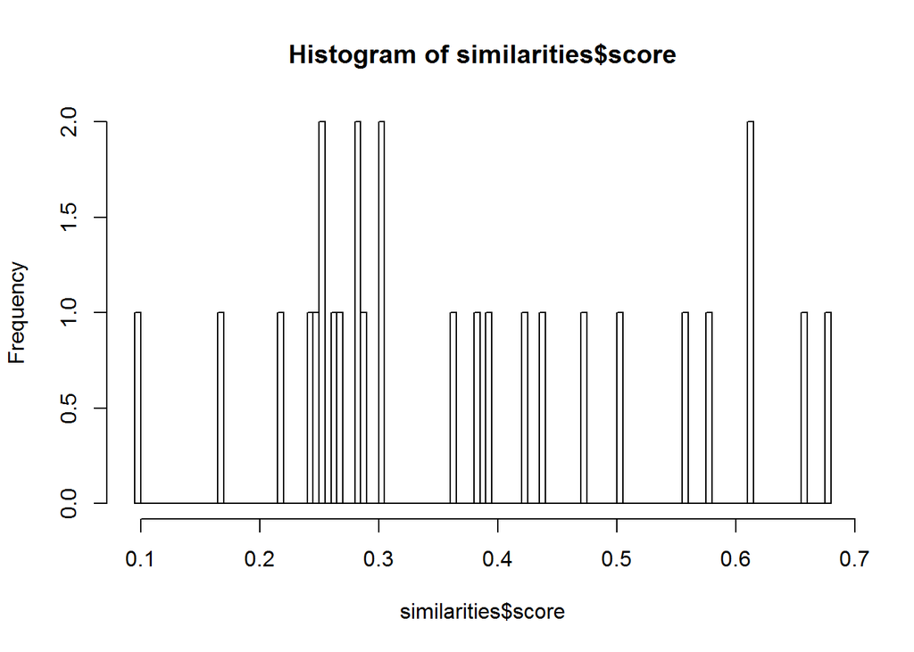

```r
hist(similarities$score, breaks = 100)
```

```r
THRESHOLD <- 0.2
```